# Analysis of Atomic Configuration Data of Amorphous Silica

In this tutorial, we will analyze the atomic configuration data of amorphous silica, following our previous analysis of crystalline copper.

## Preparation

For this analysis, you will need ASE and py3Dmol, just like in the crystalline copper analysis. If you have already completed the tutorial on crystalline copper, these libraries should already be installed.

## Downloading the Data

The data used for this analysis can be downloaded from https://isaacs.sourceforge.net/ex.html. By running the cell below, the data will be downloaded automatically.

```python
import urllib
data = urllib.request.urlopen("https://isaacs.sourceforge.net/tests/sio2-cart.chem3d").read()
with open("sio2-cart.chem3d", mode="wb") as f:
    f.write(data)
```

## File Format Conversion

Since ASE and py3Dmol do not support the Chem3D file format, we need to convert the data into the XYZ format.

```python
import re

with open("sio2-cart.chem3d") as infile:
    with open("sio2-cart.xyz", "w") as outfile:
        outfile.write(infile.readline())
        outfile.write("SiO2\n")
        for line in infile:
            atom, index, x, y, z = re.split(r"\s+", line.strip())
            outfile.write(f"{atom} {x} {y} {z}\n")
```

## Loading the File

We will use ASE to load the data after it has been converted.

```python
import ase
import ase.io
import homcloud.interface as hc
import numpy as np
import py3Dmol
import io
import homcloud.py3dmolhelper as py3dmolhelper
```

```python
sio2 = ase.io.read("sio2-cart.xyz")
```

## Visualization of amorphous silica

We will use py3Dmol to visualize the 3D structure of amorphous silica.

```python
with open("sio2-cart.xyz") as f:
    sio2_xyz = f.read()
```

```python
view = py3Dmol.view()
view.addModel(sio2_xyz, "xyz")
view.setStyle({'stick': {"colorscheme": "default"}})
view.addStyle({"sphere": {"scale": 0.3}})
view.zoomTo()
view.show()
```

3Dmol.js failed to load for some reason. Please check your browser console for error messages.

```python
sio2
```

```
Atoms(symbols='O2000Si1000', pbc=False)
```

## Calculating PDs

We will calculate the PDs. Here, we use `sio2.get_chemical_symbols()` to obtain the atomic species (such as 'O' and 'Si') and assign this information to each point by `vertex_symbols` parameter.

```python
hc.PDList.from_alpha_filtration(sio2.get_positions(),
                                vertex_symbols=sio2.get_chemical_symbols(),
                                save_boundary_map=True,
                                save_to="sio2.pdgm")
```

```
PDList(path=sio2.pdgm)
```

## Analysis of 1-dimensional PD

Let's plot the 1-dimensional PD.

```python
pd1 = hc.PDList("sio2.pdgm").dth_diagram(1)
```

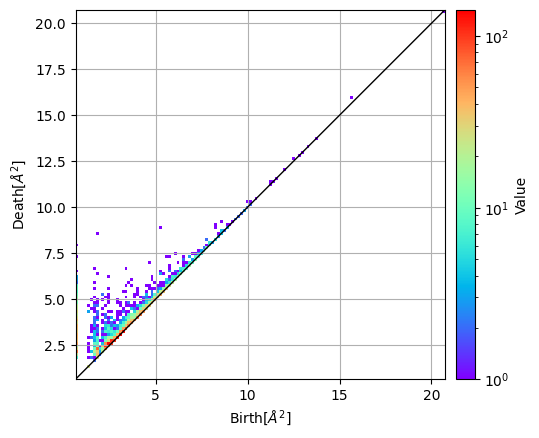

```python
pd1.histogram().plot(colorbar={"type": "log"}, unit_name="$\\AA^2$")
```

Zoom in on the lower left area.

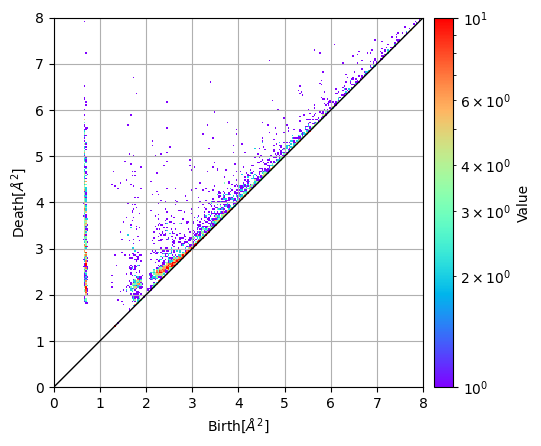

```python
pd1.histogram((0, 8), 256).plot(colorbar={"type": "log", "max": 10}, unit_name="$\\AA^2$")
```

The pairs are vertically distributed around a birth time of approximately 0.7. Let's select one point from this region and examine it in detail.

```python
pair = pd1.nearest_pair_to(0.7, 4.0)
pair
```

```
Pair(0.6844174999999998, 3.9994768570248276)
```

```python
stable_volume = pair.stable_volume(0.01)
```

When inverse analysis was applied to this pair, a ring structure composed of the following points was detected.

```python
stable_volume.boundary_points()
```

```
[[-9.603, -9.559, 1.597],
 [-10.398, -14.357, 1.84],
 [-8.603, -5.624, 0.501],
 [-5.639, -4.191, 7.279],
 [-7.506, -3.719, 4.804],
 [-10.06, -8.238, 2.43],
 [-7.814, -8.827, -0.738],
 [-5.83, -5.47, 9.373],
 [-8.239, -12.941, -1.155],
 [-7.0, -5.139, 5.33],
 [-8.946, -7.346, 7.504],
 [-7.953, -4.238, 1.024],
 [-7.123, -8.344, 0.673],
 [-7.385, -7.487, 9.515],
 [-7.628, -6.841, 0.923],
 [-8.222, -3.702, 3.441],
 [-6.028, -6.958, 8.796],
 [-10.073, -11.659, 3.81],
 [-8.811, -7.828, 9.084],
 [-5.895, -3.961, 8.813],
 [-9.057, -8.223, 6.139],
 [-9.508, -10.811, 2.543],
 [-10.167, -13.282, 4.091],
 [-9.609, -7.204, 3.434],
 [-8.925, -7.408, 4.76],
 [-9.633, -13.041, -0.301],
 [-9.838, -14.651, 3.234],
 [-10.892, -13.612, 0.54],
 [-8.686, -10.033, -1.214],
 [-7.848, -11.389, -1.05],
 [-5.691, -5.448, 6.213],
 [-7.933, -3.018, 2.003]]
```

The `boundary_points_symbols` function allows you to retrieve atomic name information as specified by `vertex_symbols`.

```python
stable_volume.boundary_points_symbols()
```

```
['Si',
 'O',
 'Si',
 'O',
 'Si',
 'O',
 'O',
 'O',
 'Si',
 'O',
 'O',
 'O',
 'Si',
 'O',
 'O',
 'O',
 'Si',
 'Si',
 'Si',
 'Si',
 'Si',
 'O',
 'O',
 'Si',
 'O',
 'O',
 'Si',
 'Si',
 'Si',
 'O',
 'Si',
 'Si']
```

The ring includes silicon (Si) and oxygen (O) atoms.

Let's examine the arrangement of atoms along the ring. This can be obtained using `boundary_loop_symbols`.

```python
stable_volume.boundary_loop_symbols()
```

```
['Si',
 'O',
 'Si',
 'O',
 'Si',
 'O',
 'Si',
 'O',
 'Si',
 'O',
 'Si',
 'O',
 'Si',
 'O',
 'Si',
 'O',
 'Si',
 'O',
 'Si',
 'O',
 'Si',
 'O',
 'Si',
 'O',
 'Si',
 'O',
 'Si',
 'O',
 'Si',
 'O',
 'Si',
 'O']
```

The ring structure is formed by alternating Si and O atoms, in a pattern like Si–O–Si–O–...

Let's visualize the ring structure.

```python
view = py3Dmol.view()
view.addModel(sio2_xyz, "xyz")
# Display the bonds as semi-transparent
view.setStyle({'stick': {"colorscheme": "default", "opacity": 0.8}})
# Also display the atoms as semi-transparent
view.addStyle({"sphere": {"scale": 0.3, "opacity": 0.8}})
py3dmolhelper.add_edges(view, stable_volume.boundary(), "green", 0.4)

view.zoomTo()
view.show()
```

3Dmol.js failed to load for some reason. Please check your browser console for error messages.

It appears to be a ring structure formed by chemical bonds between Si and O. Let's define the `show_atoms` function, which we also used in the analysis of copper crystal data, to visualize this local structure.

```python
def show_atoms(atoms):
    f = io.StringIO()
    ase.io.write(f, atoms, format="xyz")

    view = py3Dmol.view()
    view.addModel(f.getvalue(), "xyz")
    view.setStyle({'stick': {"colorscheme": "default"}})
    view.addStyle({"sphere": {"scale": 0.3}})
    view.zoomTo()
    view.show()
```

```python
show_atoms(sio2[stable_volume.boundary_loop(by="vindexes")])
```

3Dmol.js failed to load for some reason. Please check your browser console for error messages.

It would be helpful to extract several other points from this vertical distribution and examine them in the same way.

Next, let's examine the region where the pairs are densely distributed, specifically in the range 2≤birth,death≤3.

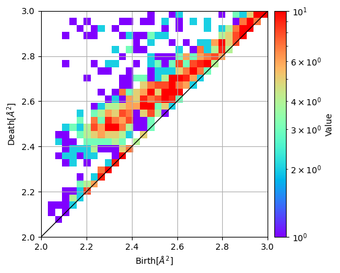

```python
pd1.histogram((2, 3), 32).plot(colorbar={"type": "log", "max": 10}, unit_name="$\\AA^2$")
```

What kind of structure do these densely clustered pairs correspond to? Let's start by extracting and examining one pair located at (2.6, 2.65).

```python
pair = pd1.nearest_pair_to(2.6, 2.65)
```

```python
stable_volume = pair.stable_volume(0.005)
```

```python
stable_volume.boundary_points()
```

```
[[-11.455, 15.303, -16.128],
 [-11.802, 12.164, -16.776],
 [-12.979, 14.928, -16.684]]
```

```python
stable_volume.boundary_points_symbols()
```

```
['Si', 'O', 'O']
```

```python
view = py3Dmol.view()
view.addModel(sio2_xyz, "xyz")
view.setStyle({'stick': {"colorscheme": "default", "opacity": 0.8}})  # 棒の部分は半透明で
view.addStyle({"sphere": {"scale": 0.3, "opacity": 0.8}})  # ボールの部分も半透明で
py3dmolhelper.add_edges(view, stable_volume.boundary(), "green", 0.4)

view.zoomTo()
view.show()
```

3Dmol.js failed to load for some reason. Please check your browser console for error messages.

```python
show_atoms(sio2[stable_volume.boundary_loop(by="vindexes")])
```

3Dmol.js failed to load for some reason. Please check your browser console for error messages.

In persistent diagram computations, chemical bonding information is ignored; instead, structures are extracted by expanding radii around atoms. This allows us to uncover structural features that are not visible when relying solely on bonding information, which is one of the key advantages of persistent homology analysis.

Upon examining this distribution more closely, we find that various configurations, such as a ring with one silicon atom and two oxygen atoms, are intermixed. If you wish to investigate this further, applying statistical analysis to the inverse analysis results would be a good approach.

# Exercises

1. In the example of amorphous silica, try numbering atoms as "Si0001", "Si0002", and so on.
2. Try performing PH analysis on your interesting atomic configuration data.

# Advanced Topic

## Setting Initial Atomic Radii

To incorporate atomic species into persistent homology analysis, you can assign initial radii to each type of atom. In the following example, the radii are set to 1.275 for oxygen (O) and 0.375 for silicon (Si).

These values were used in the PH analysis of amorphous silica, as reported in the following paper: https://www.pnas.org/content/113/26/7035.full. For details on how these initial radii were determined, please refer to the paper.

Note that the radii must be **squared** before being used in the analysis. This is a spec of HomCloud.

```python
weights = np.array([1.275**2 if atom == "O" else 0.375**2 for atom in sio2.get_chemical_symbols()])
```

```python
pd1 = hc.PDList.from_alpha_filtration(
    sio2.get_positions(),
    weight=weights,
    vertex_symbols=sio2.get_chemical_symbols(),
    save_boundary_map=True
).dth_diagram(1)
```

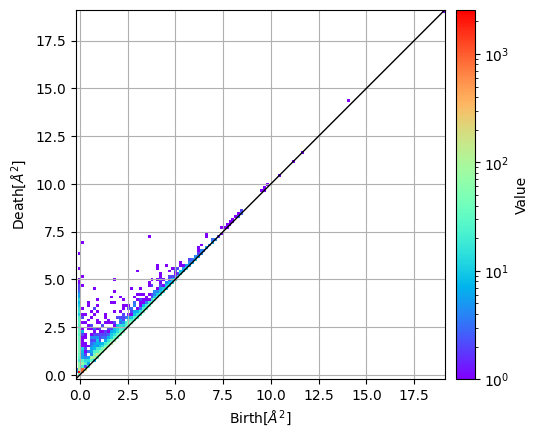

```python
pd1.histogram().plot(colorbar={"type": "log"}, unit_name="$\\AA^2$")
```

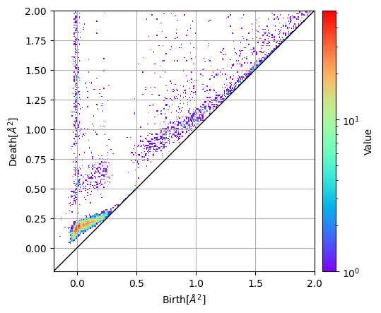

```python
pd1.histogram((-0.2, 2), 256).plot(colorbar={"type": "log"}, unit_name="$\\AA^2$")
```

```python
pair = pd1.nearest_pair_to(0.00, 0.2)
stable_volume = pair.stable_volume(0.005)
stable_volume.boundary_points_symbols()
```

```
['O', 'O', 'Si']
```

```python
view = py3Dmol.view()
view.addModel(sio2_xyz, "xyz")
view.setStyle({'stick': {"colorscheme": "default", "opacity": 0.8}})  # 棒の部分は半透明で
view.addStyle({"sphere": {"scale": 0.3, "opacity": 0.8}})  # ボールの部分も半透明で
py3dmolhelper.add_edges(view, stable_volume.boundary(), "green", 0.4)

view.zoomTo()
view.show()
```

3Dmol.js failed to load for some reason. Please check your browser console for error messages.

```python
show_atoms(sio2[stable_volume.boundary_loop(by="vindexes")])
```

3Dmol.js failed to load for some reason. Please check your browser console for error messages.

The pairs densely distributed around (0, 0.2) appear to correspond to the triangular structures formed by O-Si-O atoms.

```python
pair = pd1.nearest_pair_to(0.71, 0.85)
stable_volume = pair.stable_volume(0.005)
stable_volume.boundary_points_symbols()
```

```
['O', 'O', 'O']
```

```python
view = py3Dmol.view()
view.addModel(sio2_xyz, "xyz")
view.setStyle({'stick': {"colorscheme": "default", "opacity": 0.8}})  # 棒の部分は半透明で
view.addStyle({"sphere": {"scale": 0.3, "opacity": 0.8}})  # ボールの部分も半透明で
py3dmolhelper.add_edges(view, stable_volume.boundary(), "green", 0.4)

view.zoomTo()
view.show()
```

3Dmol.js failed to load for some reason. Please check your browser console for error messages.

```python
show_atoms(sio2[stable_volume.boundary_loop(by="vindexes")])
```

3Dmol.js failed to load for some reason. Please check your browser console for error messages.

The diagonally extending distribution from (0.5, 0.75) to (1.5, 1.5) appears to correspond to triangular structures formed by three oxygen atoms.

The vertically distributed pairs with a birth value of 0.0 correspond to loop structures formed by Si-O-Si-… bonding, but applying inverse analysis reveals somewhat different structural characteristics.

```python
pair = pd1.nearest_pair_to(0.00, 1.50)
stable_volume = pair.stable_volume(0.005)
stable_volume.boundary_points_symbols()
```

```
['O', 'Si', 'O', 'Si', 'O', 'O', 'O', 'O', 'O']
```

While there are sequences where O-Si-O atoms are aligned, there are also sequences where O-O alignments can be observed. This is because the initial radii are set based on the following criteria:

- Adjacent Si and O atoms are, on average, in contact at their initial radii
- The two nearest O atoms are also, on average, in contact at their initial radii

As a result, whether Si-O or O-O contact is prioritized depends on slight fluctuations in the interatomic distances.

By adjusting the weights in this way, structures that were previously difficult to observe can become more apparent, while other structures may, in turn, become less visible.

## Advanced Topic 2: Computing PDs Using Only a Subset of Atoms

When analyzing materials composed of multiple types of atoms, in addition to assigning different weights (initial radii) to each atom type as described earlier, another approach is to compute the persistence diagrams using only a specific type of atoms.  
Here, let's try calculating the PD using only oxygen atoms, excluding silicon.

To do this, we need to extract the indices of only the oxygen atoms.  
Since we can check the atomic species using `get_chemical_symbols`, we can use a Python list comprehension to create a list of indices for the oxygen atoms as shown below.

```python
o_atom_indexes = [i for (i, symbol) in enumerate(sio2.get_chemical_symbols()) if symbol == "O"]
print(o_atom_indexes)
```

```
[0, 1, 2, 3, 4, 5, 6, 7, 8, 9, 10, 11, 12, 13, 14, 15, 16, 17, 18, 19, 20, 21, 22, 23, 24, 25, 26, 27, 28, 29, 30, 31, 32, 33, 34, 35, 36, 37, 38, 39, 40, 41, 42, 43, 44, 45, 46, 47, 48, 49, 50, 51, 52, 53, 54, 55, 56, 57, 58, 59, 60, 61, 62, 63, 64, 65, 66, 67, 68, 69, 70, 71, 72, 73, 74, 75, 76, 7…
```

The following code makes the data consisting only of oxygens.

```python
sio2_only_o = sio2[o_atom_indexes]
```

```python
show_atoms(sio2_only_o)
```

3Dmol.js failed to load for some reason. Please check your browser console for error messages.

The following codes compute PDs and plot them.

```python
hc.PDList.from_alpha_filtration(sio2_only_o.get_positions(),
                                vertex_symbols=sio2_only_o.get_chemical_symbols(),
                                save_boundary_map=True,
                                save_to="sio2_only_o.pdgm")
```

```
PDList(path=sio2_only_o.pdgm)
```

```python
pd1 = hc.PDList("sio2_only_o.pdgm").dth_diagram(1)
```

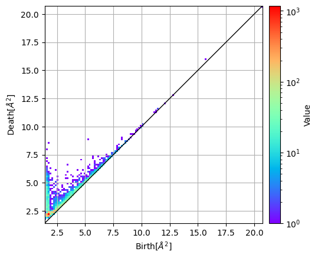

```python
pd1.histogram().plot(colorbar={"type": "log"}, unit_name="$\\AA^2$")
```

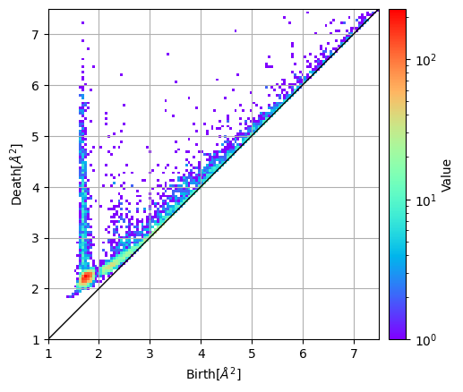

```python
pd1.histogram((1.0, 7.5), 128).plot(colorbar={"type": "log"}, unit_name="$\\AA^2$")
```

If you want to examine the PDs in more details, try applying inverse analysis.